# Cyclist Bike-Share Markdown

Chris Brady

9/20/2021

## R Markdown

This project was built to explore a dataset for a fictional ride share company called Cyclistic.

This analysis will attempt to find any notable differences between different user groups and make reccomendations to the marketing team on how to convert casual users into annual members.

First the environment was set up and the dataset was downloaded from https://divvy-tripdata.s3.amazonaws.com/index.html/Divvy_Trips_2020_Q1. Then, imported into Rstudio

```r
library(lubridate)
library(tidyverse)
library(readr)
bike_Data1 <- read_csv("/Users/selinnaescabi/Desktop/Cyclistic Bike-Share Dataset/Divvy_Trips_2020_Q1.csv")
```

Once the data was imported, it was transformed to include columns that tracked the length of individual rides in seconds, and what day of the week the ride was started on.

```r
bike_data_with_ride_length <- bike_Data1 %>%
  mutate(time_of_ride = bike_Data1$ended_at - bike_Data1$started_at )

add_weekday <- bike_data_with_ride_length %>%
  mutate(dayOfRide = wday(started_at, label= TRUE))

#update data set to have weekday column
bike_data_with_ride_length <- add_weekday

bike_data_with_ride_length
```

```
## # A tibble: 426,887 × 15
##    ride_id          rideable_type started_at          ended_at
##    <chr>            <chr>         <dttm>              <dttm>
##  1 EACB19130B0CDA4A docked_bike   2020-01-21 20:06:59 2020-01-21 20:14:30
##  2 8FED874C809DC021 docked_bike   2020-01-30 14:22:39 2020-01-30 14:26:22
##  3 789F3C21E472CA96 docked_bike   2020-01-09 19:29:26 2020-01-09 19:32:17
##  4 C9A388DAC6ABF313 docked_bike   2020-01-06 16:17:07 2020-01-06 16:25:56
##  5 943BC3CBECCFD662 docked_bike   2020-01-30 08:37:16 2020-01-30 08:42:48
##  6 6D9C8A6938165C11 docked_bike   2020-01-10 12:33:05 2020-01-10 12:37:54
##  7 31EB9B8F406D4C82 docked_bike   2020-01-10 13:07:35 2020-01-10 13:12:24
##  8 A2B24E3F9C9720E3 docked_bike   2020-01-10 07:24:53 2020-01-10 07:29:50
##  9 5E3F01E1441730B7 docked_bike   2020-01-31 16:37:16 2020-01-31 16:42:11
## 10 19DC57F7E3140131 docked_bike   2020-01-31 09:39:17 2020-01-31 09:42:40
## # … with 426,877 more rows, and 11 more variables: start_station_name <chr>,
## #   start_station_id <dbl>, end_station_name <chr>, end_station_id <dbl>,
## #   start_lat <dbl>, start_lng <dbl>, end_lat <dbl>, end_lng <dbl>,
## #   member_casual <chr>, time_of_ride <drtn>, dayOfRide <ord>
```

Some columns in this newly transformed data set have a negative number for time of ride. The data was then filtered to make sure it only contained valid ride times.

```r
corrected_ride_length <- bike_data_with_ride_length %>%
  filter(time_of_ride >= 0)

#set back original variable name for cleaned data
bike_data_with_ride_length <- corrected_ride_length
```

Now that the data is properly cleaned and transformed, I implememted the ggplot2 package to display the first visualization that will compare the ride lengths between the casual members and annual members.

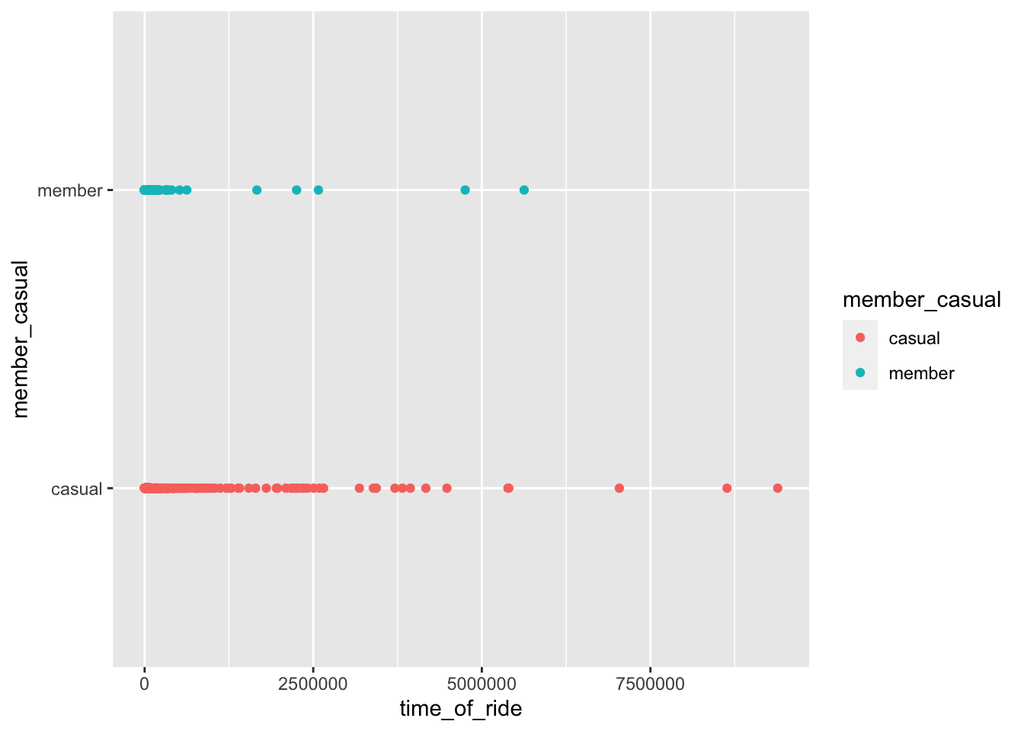

```r
ggplot(data = bike_data_with_ride_length) +

  geom_point(mapping = aes(x = time_of_ride, y = member_casual, color = member_casual))
```

Based on this visual, it appears that the casual members ride time tends to be longer than the annual members ride time.

To investigate this further, I created two small data frames from the original cleaned dataset. One dataframe contains the median ride length for both the casual and annual members, and the other contains the average ride length for both memberships.

```r
members <-bike_data_with_ride_length%>%
  filter(member_casual == "member")

casual_members <- bike_data_with_ride_length %>%
  filter(member_casual == "casual")
#create data frame that contains observations for median ride length for casuals and members respectively
casual_members
```

```
## # A tibble: 48,363 × 15
##    ride_id          rideable_type started_at          ended_at
##    <chr>            <chr>         <dttm>              <dttm>
##  1 3479141FF24AD595 docked_bike   2020-01-16 17:10:39 2020-01-16 17:40:40
##  2 CDA4546AFB6F34F5 docked_bike   2020-01-05 13:54:08 2020-01-05 14:24:03
##  3 69A8CB6748CA2DB0 docked_bike   2020-01-22 15:11:17 2020-01-22 17:15:50
##  4 1DD6245D8E796F48 docked_bike   2020-01-29 22:44:04 2020-01-29 22:53:53
##  5 7C3CF816107BE767 docked_bike   2020-01-20 10:45:43 2020-01-20 11:27:02
##  6 6C2A73560288FFFA docked_bike   2020-01-17 17:34:08 2020-01-17 19:27:02
##  7 8504E5A7AF4F7036 docked_bike   2020-01-22 16:51:21 2020-01-22 17:07:02
##  8 1F27EDB7492AC2E1 docked_bike   2020-01-03 14:38:54 2020-01-03 15:07:04
##  9 BC608BC10D868760 docked_bike   2020-01-27 16:38:15 2020-01-27 17:19:02
## 10 DF1928D0565EC7CC docked_bike   2020-01-02 16:08:22 2020-01-02 16:26:26
## # … with 48,353 more rows, and 11 more variables: start_station_name <chr>,
## #   start_station_id <dbl>, end_station_name <chr>, end_station_id <dbl>,
## #   start_lat <dbl>, start_lng <dbl>, end_lat <dbl>, end_lng <dbl>,
## #   member_casual <chr>, time_of_ride <drtn>, dayOfRide <ord>
```

```r
median_Diffs <- data.frame("Median_Ride_Time" = c(median(casual_members$time_of_ride),
                                                     median(members$time_of_ride)),
                              member_casual = c("casual", "member"))

#create data frame that contains observations for average ride length for casuals and members respectively

average_Diffs <- data.frame("Average_Ride_Time" = c(mean(casual_members$time_of_ride),
                                                   mean(members$time_of_ride)),
                            member_casual = c("casual", "member"))
```

From these two data frames, bar charts are used to visualize the difference in ride length between both memberships:

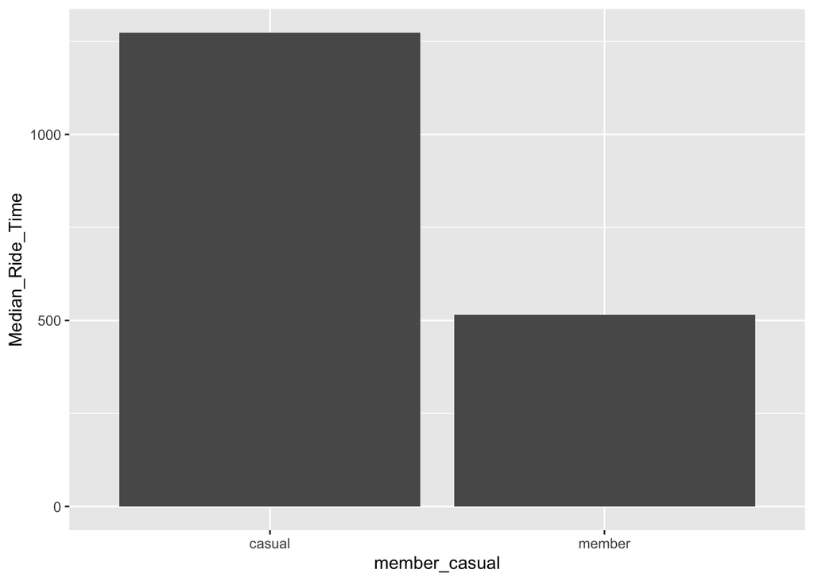

```r
ggplot(data = median_Diffs) +
  geom_bar(mapping = aes(x = member_casual, y = Median_Ride_Time), stat = 'identity')
```

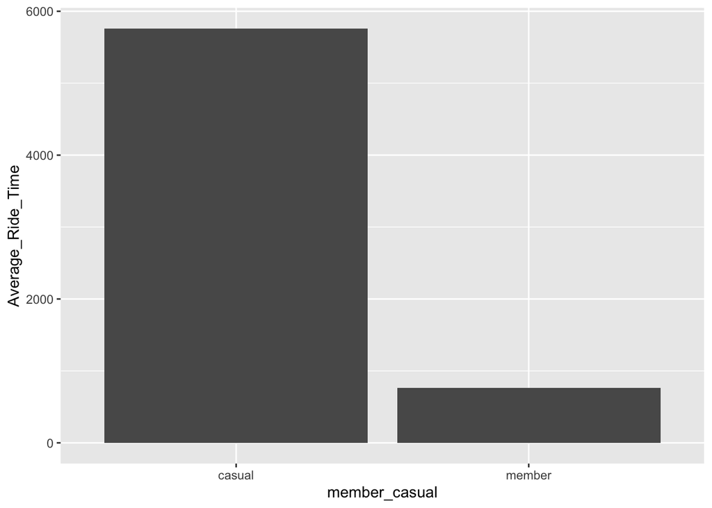

```r
ggplot(data = average_Diffs) +
  geom_bar(mapping = aes(x = member_casual, y = Average_Ride_Time), stat = 'identity')
```

Both of these charts clearly show a significant difference in ride length between the memberships. The casual member on average tends to have much longer ride lengths than the annual rider.

Next, the riders for each day of the week were examined to see if there were notable differences in when a rider of a certain membership would use the service.

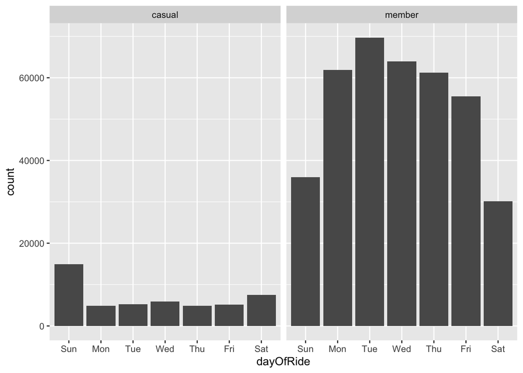

```r
bike_data_with_ride_length %>%
  ggplot(aes(x = dayOfRide)) +geom_bar() + facet_wrap(~member_casual)
```

Based on the bar charts above, it appears that casual riders tend to ride more on weekends, and annual members tend to ride more during the week.

Conclusion.

This analysis was tasked with identifying the differences between bicycle riders who have an annual membership vs. a casual membership (a day pass).

From this data, it looks like annual members are utilizing their membership for shorter rides during time periods where most people work, and casual members are utilizing the service for long rides on weekends. While it may be worth surveying riders to see how they view their use of the service, I don’t think it is unreasonable to conclude that annual members may view their membership as an all-purpose transportation method while casuals view it for more leisurely activities.